# Gsynth implementation

```r
print(paste0("Nº `Control` (Treated) = ", out_n2$Nco))
```

```
[1] "Nº `Control` (Treated) = 4"
```

```r
print(paste0("Nº non-treated = ", out_n2$Ntr))
```

```
[1] "Nº non-treated = 3"
```

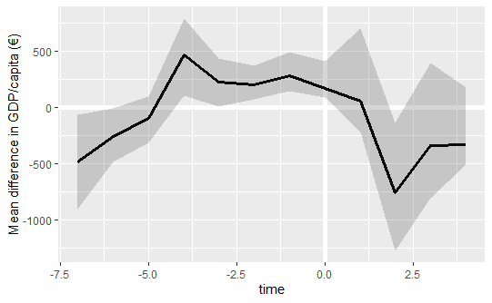

```r
plot(out_n2, xlim = c(-8, 4),
     main = "",
     ylab = "Mean difference in GDP/capita (€)")
```

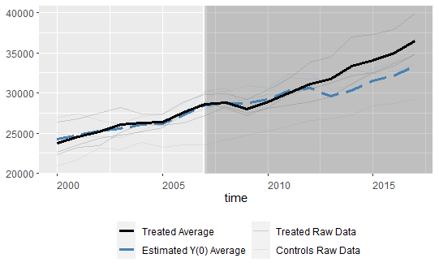

```r
# plot all data:
plot(out_n2, type = "counterfactual",
     raw = "all", main="") # Why the final dip
```

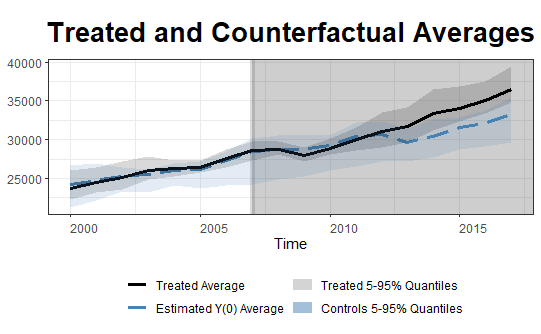

```r
# We can also add two 5 to 95% quantile bands of the treated and control outcomes as references to make sure the estimated counterfactuals are not results of severe extrapolations.

plot(out_n2, type = "counterfactual",
     raw = "band", xlab = "Time",
     # ylim = c(-5,35),
     theme.bw = TRUE)
```

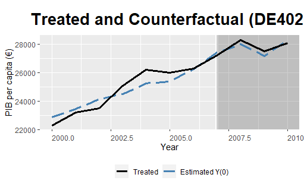

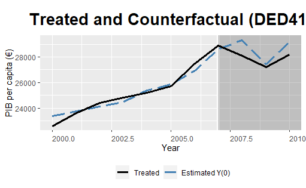

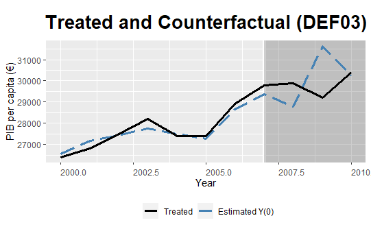

```r
for (i in fake_tr_dta[!is.na(fake_tr_dta$year_announced), ]$geo %>% unique()){
  if (i %in% out_n2$id.tr){
    placebo_plot <- plot(
      out_n2, type = "counterfactual", id = i,
      xlim = c(2000, fake_tr_dta[fake_tr_dta$geo == i,
                                 ]$year_announced[1]-1),
      # main = "",
      xlab = "Year",
      ylab = "PIB per capita (€)"
    )

    final_plot <- placebo_plot +
    scale_x_continuous(
      labels = scales::number_format(accuracy = 1,
                                     big.mark = "")) +
      theme(axis.text.x = element_text(hjust=0.5))
    pdf(file=paste0("images/prelim_results/plac2011/ind_inverse_placebo",
                    "_",  i, ".pdf"),
        width = 3.5, height = 3.1)
    plot(final_plot)
    dev.off()
  }
}
```

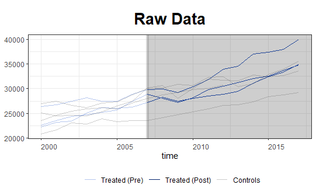

```r
plot(out_n2, type = "raw", theme.bw = TRUE)
```

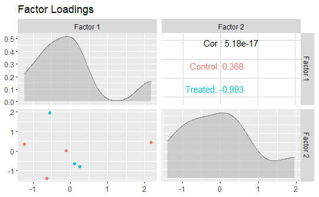

```r
plot(out_n2, type = "loadings")
```

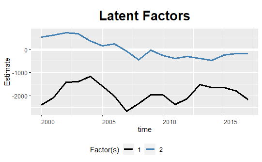

```r
plot(out_n2, type = "factors")
```

##### Real Inver

```r
fake_tr_dta_real <- fake_tr_dta %>%
  # fake treated that have good synths(prev.step) or real treated
  filter(geo %in% out_n2$id.tr | treated_uz)

# Delete years of Magdeburg after the 2013 floods
n3_dta <- n3_dta %>%
  filter(!(geo == "DEE03" & time >= 2013))

out_n2 <- gsynth(gdp_eur_hab ~ is_treated,
               data = fake_tr_dta_real,
               index = c("geo","time"),
               na.rm = TRUE, # remove
               force = "time", # unit or time fixed effects or both?
               # CV = TRUE,
               r = c(0, 3), # an integer specifying the number of factors. If CV = TRUE, the cross validation procedure will select the optimal number of factors from r to 5.
               se = TRUE,
               EM = TRUE, # Gobillon and Magnac (takes a lot of time)
               inference = "parametric",
               # estimator = "mc",
               nboots = 1000,  #500
               parallel = TRUE, cores = 5, # if do parallel and how many cores
               min.T0 = 7) # Has to be larger than r.max+1
```

```
Parallel computing ...
Cross-validating ...

 r = 0; sigma2 = 3517342.85714; IC = 15.07322; MSPE = 1930284.09091
 r = 1; sigma2 = 471878.77710; IC = 14.16972; MSPE = 783180.16881*
 r = 2; sigma2 = 249247.28929; IC = 14.54458; MSPE = 851597.64558
 r = 3; sigma2 = 263202.43570; IC = 15.52009; MSPE = 2060195.59427

 r* = 1


Bootstrapping ...
```

```r
out_n2 %>% print()
```

```
Call:
gsynth.formula(formula = gdp_eur_hab ~ is_treated, data = fake_tr_dta_real,
    na.rm = TRUE, index = c("geo", "time"), force = "time",
    r = c(0, 3), EM = TRUE, se = TRUE, nboots = 1000, inference = "parametric",
    parallel = TRUE, cores = 5, min.T0 = 7)

Average Treatment Effect on the Treated:
 ATT.avg  S.E. CI.lower CI.upper p.value
    1948 294.4     1414     2591       0

   ~ by Period (including Pre-treatment Periods):
        ATT  S.E. CI.lower CI.upper p.value n.Treated
1  -397.720 268.4  -906.60    157.0   0.144         0
2  -166.274 292.7  -738.11    434.1   0.626         0
3   -11.047 287.4  -556.41    563.3   0.984         0
4   548.727 350.1  -123.72   1269.3   0.116         0
5   280.273 260.6  -228.42    803.4   0.278         0
6   240.483 107.0    47.42    454.7   0.020         0
7   336.877 149.8    68.85    646.3   0.020         0
8   207.005 249.1  -303.58    694.9   0.358         0
9     8.723 281.9  -528.85    550.6   0.998         0
10 -295.747 369.2  -982.51    484.5   0.472         0
11 -168.686 181.2  -499.48    225.4   0.436         0
12 -330.573 334.2  -926.73    316.2   0.392         3
13  469.590 290.6   -66.93   1107.6   0.076         3
14 1871.808 701.1   598.16   3312.0   0.002         3
15 2751.577 912.8  1079.41   4609.4   0.002         3
16 2552.190 270.8  2087.81   3153.5   0.000         3
17 2958.316 223.7  2581.85   3436.8   0.000         3
18 3362.977 366.8  2695.59   4139.4   0.000         3
```

```r
print(paste0("Nº `Control` (Treated) = ", out_n2$Nco))
```

```
[1] "Nº `Control` (Treated) = 4"
```

```r
print(paste0("Nº non-treated = ", out_n2$Ntr))
```

```
[1] "Nº non-treated = 3"
```

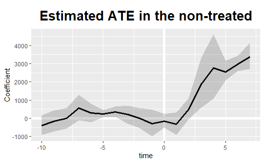

```r
plot(out_n2, main = "Estimated ATE in the non-treated")#, ylim = c(-5000, 2000))

ATT_plot <- out_n2$est.att %>%
  as_tibble(rownames = "rel_time") %>%
  mutate(
    # This puts 2010 as the year "0"
    rel_time = as.numeric(rel_time)-10+2010,
    # This gives the real ATC as the "treated" are not really treated
    ATT = -ATT, CI.lower = -CI.lower, CI.upper = -CI.upper) %>%
  ggplot(aes(x= rel_time, y = ATT, group = 1)) +
  geom_ribbon(aes(ymin = CI.lower, ymax = CI.upper),
              alpha = 0.3) +
  # geom_vline(xintercept = 2011) +
  geom_segment(x = 2011, xend = 2011, y = -5000, yend = 1000,
               size = 2, color = "grey50") +
  geom_line(size = 1.5) +
  geom_text(aes(x= rel_time, y = 1500, label = n.Treated)) +
  geom_hline(yintercept = 0) +
  labs(
    title = "",
    x = "Year",
    y = "Change in GDP per capita (€)"
  )

{
pdf(file=
      paste0("images/prelim_results/plac2011/ATT_inv_real.pdf"),
    width = 5.5, height = 3)
print(ATT_plot)
dev.off()
}
```

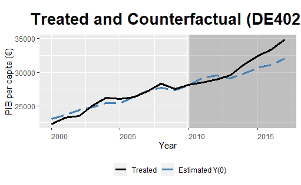

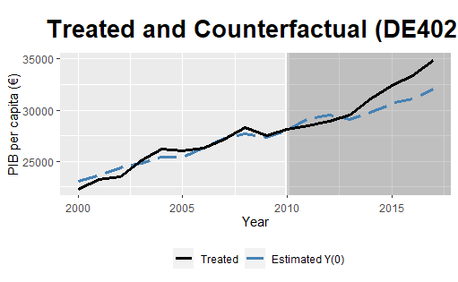

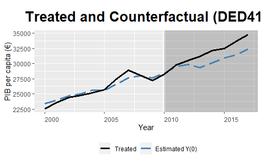

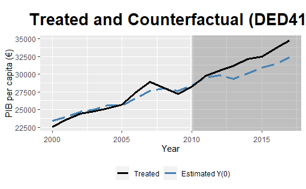

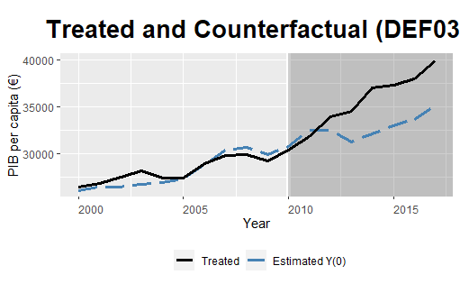

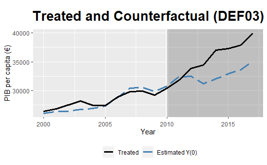

```r
# # plot all data:
# plot(out_n2, type = "counterfactual",
#      raw = "all", main="")

# We can also add two 5 to 95% quantile bands of the treated and control outcomes as references to make sure the estimated counterfactuals are not results of severe extrapolations.

# plot(out_n2, type = "counterfactual",
#      raw = "band", xlab = "Time",
#      # ylim = c(-5,35),
#      theme.bw = TRUE)

for (i in fake_tr_dta[!is.na(fake_tr_dta$year_announced), ]$geo %>%
     unique()){
  if (i %in% out_n2$id.tr){
    temp <- plot(out_n2, type = "counterfactual", id = i,
                 # main = "",
                 # main = paste0("Control and Synthetic T (",i, ")"),
                 xlab = "Year",
                 ylab = "PIB per capita (€)"
    )
    temp <- temp +
    scale_x_continuous(
      labels = scales::number_format(accuracy = 1,
                                     big.mark = "")) +
      theme(axis.text.x = element_text(hjust=0.5))

    # pdf(file=paste0("images/prelim_results/plac2011/ind_inverse_real",
    #                 "_",  i, ".pdf"),
    # width = 3.5, height = 3.1)
    print(temp)
    # dev.off()
    # print(temp + scale_fill_discrete(limits=c("2", "0.5")))
  }
}
```

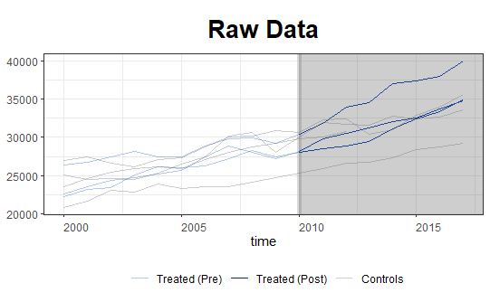

```r
plot(out_n2, type = "raw", theme.bw = TRUE)
```

```
Loadings for the first factor are shown...
```

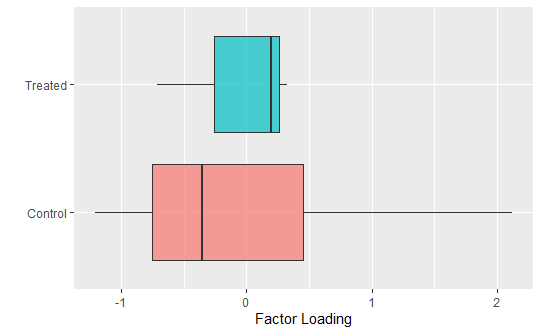

```r
plot(out_n2, type = "loadings")
```

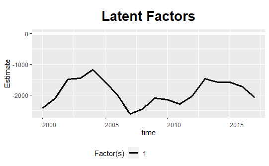

```r
plot(out_n2, type = "factors")
```

> I need to modify the graphs, titles and axis I need to have some sense of what “treatment” I am applyting to this set of controls.

#### Sum Stat

```r
cat(gsub("\\\\hline\n[^\n]+& all &[^\n]+\n", "", result))
```

```
% latex table generated in R 3.6.1 by xtable 1.8-4 package
% Thu Jul 30 19:54:19 2020
\begin{table}[ht]
\centering
\begingroup\small
\begin{tabular}{llrrrrr}
 \textbf{Variable} & \textbf{Levels} & $\mathbf{n}$ & \textbf{Min} & $\mathbf{\bar{x}}$ & \textbf{Max} & $\mathbf{s}$ \\
  \hline
gdp\_eur\_hab & Non-treated & 3 & 27911 & 29211 & 31344 & 1862 \\
   & Treated & 4 & 25011 & 27864 & 30028 & 2204 \\
      \hline
pop\_km2 & Non-treated & 3 &   632 &   919 &  1119 &  255 \\
   & Treated & 4 &   212 &  1081 &  1755 &  640 \\
      \hline
\end{tabular}
\endgroup
\caption{Summary statistics for potential effect on GDP/capita}
\label{tab: descr stat inv2012}
\end{table}
```

##### Analysis

What is the treated pool?

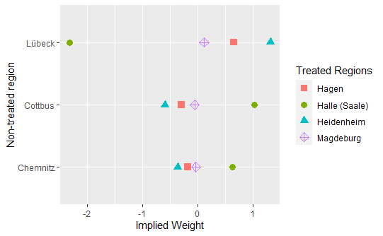

> Cottbus anf Chemniz ae both East german mid sized cities while Lübeck its a very important port city close to Hanburg in West Germany.

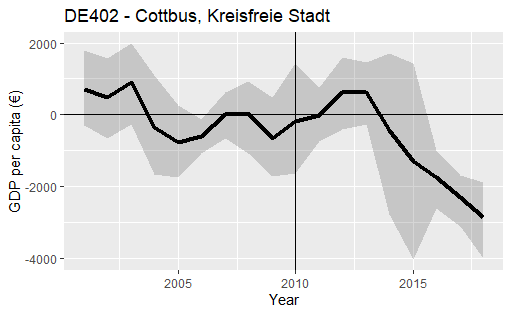

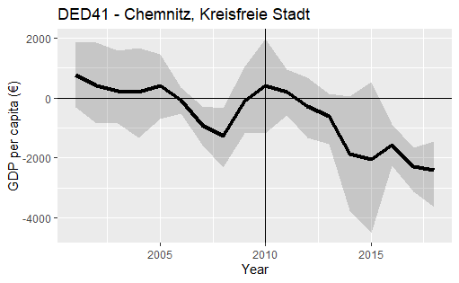

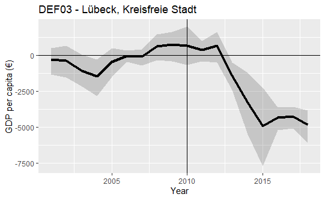

```r
library("rnaturalearthdata")
```

```r
pdf(file=paste0("images/prelim_results/plac2011/w_facet.pdf"),
    width = 5, height = 3.1)
tm_facet_map
dev.off()
```

#### Plac. 2012?

## Share of GDP

### Local trade: Retail, transport, accomodation and food

#### pre-treatment placebo (4y)

Do first analysis (look for good pre-treatment placebo):

#### 4. Only G

- Only Germany as controls
- Filter regions -> YES
- 60km buffer arround each city center
- Filter regions with high unemployment rates that are not compatiable if I am using fixed effects by region. -> YES

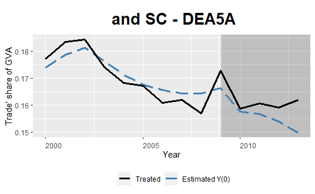

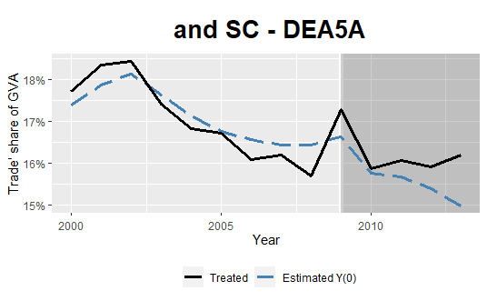

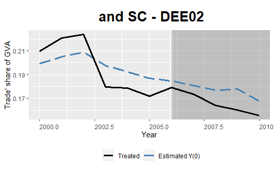

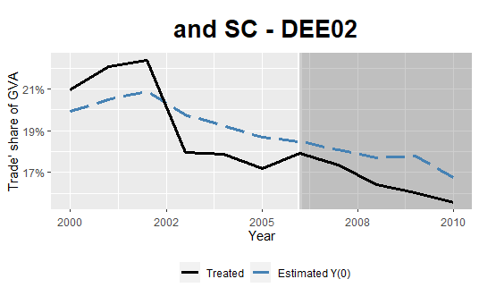

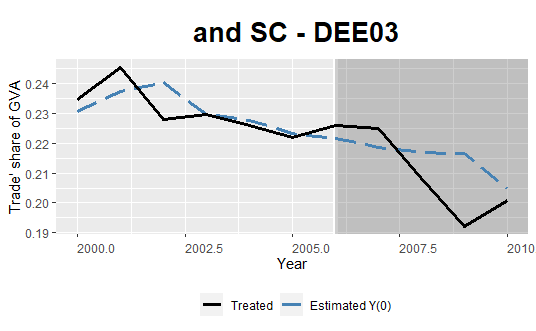